# Transformasi WLS

Andhias Abdillah Ridho

2026-06-26

```r
library(datarium)
library(dplyr)
```

```r
library(ggplot2)
library(lmtest)
data<-marketing[,c("youtube","sales")]
head(data)
```

```
##   youtube sales
## 1  276.12 26.52
## 2   53.40 12.48
## 3   20.64 11.16
## 4  181.80 22.20
## 5  216.96 15.48
## 6   10.44  8.64
```

# OLS

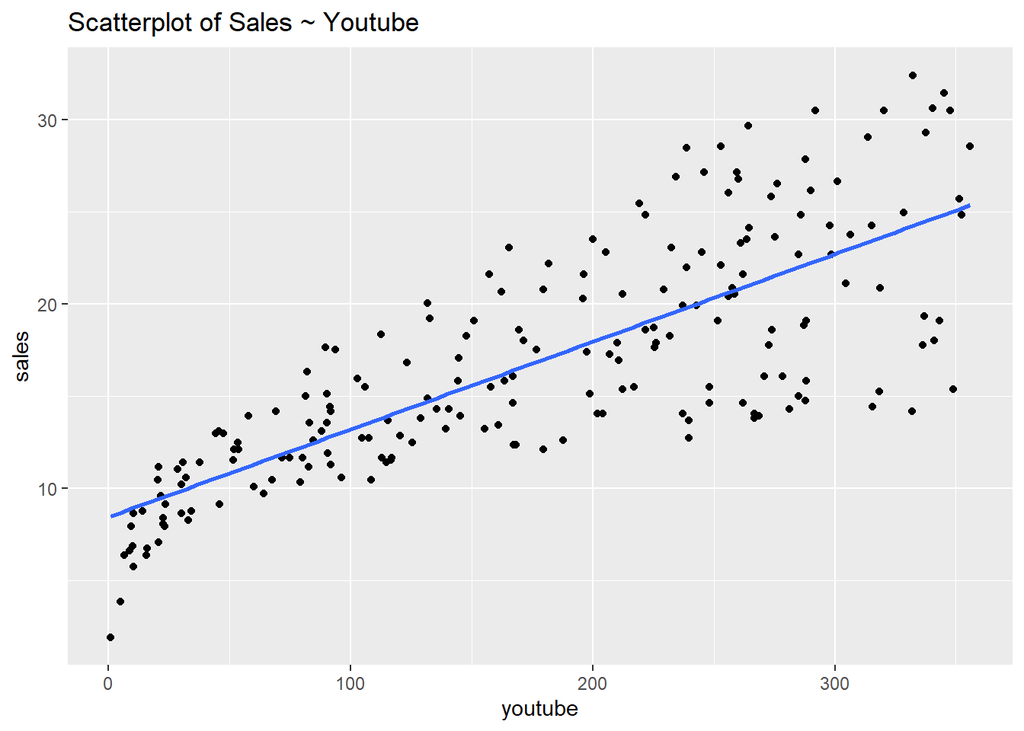

```r
ggplot(data) +
  geom_point(mapping = aes(youtube, sales)) +
  geom_smooth(mapping = aes(youtube,sales),
              method=lm, se=F)+
  labs(title = "Scatterplot of Sales ~ Youtube")
```

```r
model<-lm(sales~youtube, data=data)
summary(model)
```

```
##
## Call:
## lm(formula = sales ~ youtube, data = data)
##
## Residuals:
##      Min       1Q   Median       3Q      Max
## -10.0632  -2.3454  -0.2295   2.4805   8.6548
##
## Coefficients:
##             Estimate Std. Error t value Pr(>|t|)
## (Intercept) 8.439112   0.549412   15.36   <2e-16 ***
## youtube     0.047537   0.002691   17.67   <2e-16 ***
## ---
## Signif. codes:  0 '***' 0.001 '**' 0.01 '*' 0.05 '.' 0.1 ' ' 1
##
## Residual standard error: 3.91 on 198 degrees of freedom
## Multiple R-squared:  0.6119, Adjusted R-squared:  0.6099
## F-statistic: 312.1 on 1 and 198 DF,  p-value: < 2.2e-16
```

# Diagnostik Sisaan / Pengujian Asumsi

## Eksplorasi Grafik

### Plot Sisaan vs Yduga

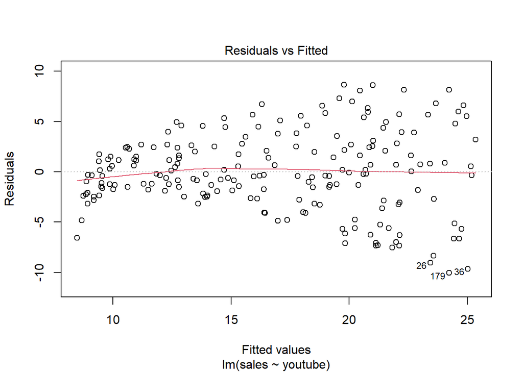

```r
plot(model,1)
```

### Plot sisaan vs urutan

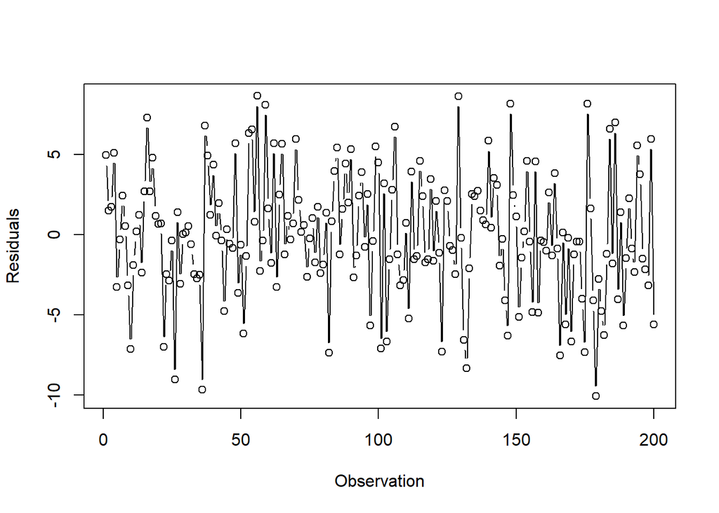

```r
plot(x = 1:dim(data)[1],
     y = model$residuals,
     type = 'b',
     ylab = "Residuals",
     xlab = "Observation")
```

Tebaran tidak berpola → sisaan saling bebas, model pas

### QQ plot

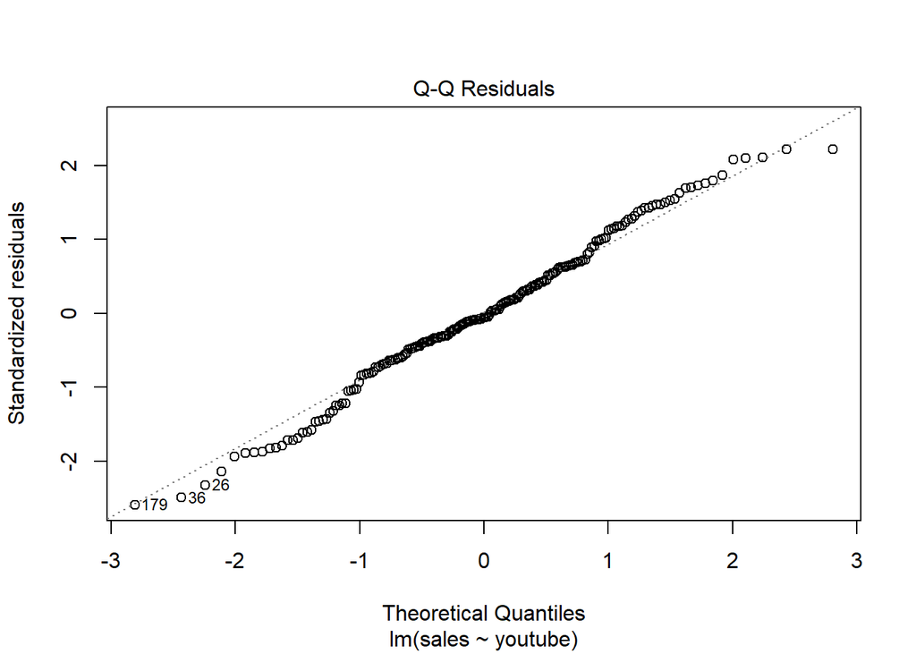

```r
plot(model,2)
```

Amatan cenderung mengikuti garis pola sehingga sisaan menyebar normal

## Uji Formal

### Nilai harapan sisaan sama dengan nol

```r
t.test(model$residuals,mu = 0,conf.level = 0.95)
```

```
##
##  One Sample t-test
##
## data:  model$residuals
## t = 9.1665e-16, df = 199, p-value = 1
## alternative hypothesis: true mean is not equal to 0
## 95 percent confidence interval:
##  -0.5438864  0.5438864
## sample estimates:
##    mean of x
## 2.528208e-16
```

Nilai p pada uji t sama dengan 1 yang lebih besar dari alpha 5%, sehingga dinyatakan asumsi nilai harapan sisaan sama dengan nol terpenuhi

### Ragam sisaan homogen

```r
bptest(model)
```

```
##
##  studentized Breusch-Pagan test
##
## data:  model
## BP = 48.038, df = 1, p-value = 4.18e-12
```

### Sisaan saling bebas

```r
dwtest(model)
```

```
##
##  Durbin-Watson test
##
## data:  model
## DW = 1.9347, p-value = 0.3213
## alternative hypothesis: true autocorrelation is greater than 0
```

Nilai p pada uji durbin watson sama dengan 0.3213 yang lebih besar dari alpha 5%, sehingga dinyatakan asumsi sisaan saling bebas terpenuhi

### Normalitas Sisaan

```r
ks.test(model$residuals, "pnorm", mean = mean(model$residuals),
        sd = sd(model$residuals))
```

```
##
##  Asymptotic one-sample Kolmogorov-Smirnov test
##
## data:  model$residuals
## D = 0.041533, p-value = 0.8806
## alternative hypothesis: two-sided
```

# WLS

## Perhitungan Weights

```r
resid_abs <- abs(model$residuals)
fit <- lm(resid_abs ~ data$youtube)
data.weights <- 1 / fit$fitted.values^2
```

## Pemodelan

```r
model.lmw <- lm(sales~ youtube,
              data = data,
              weights = data.weights)
summary(model.lmw)
```

```
##
## Call:
## lm(formula = sales ~ youtube, data = data, weights = data.weights)
##
## Weighted Residuals:
##     Min      1Q  Median      3Q     Max
## -5.2241 -0.8965 -0.1057  1.0011  2.5396
##
## Coefficients:
##             Estimate Std. Error t value Pr(>|t|)
## (Intercept) 7.561062   0.289159   26.15   <2e-16 ***
## youtube     0.053361   0.002308   23.12   <2e-16 ***
## ---
## Signif. codes:  0 '***' 0.001 '**' 0.01 '*' 0.05 '.' 0.1 ' ' 1
##
## Residual standard error: 1.249 on 198 degrees of freedom
## Multiple R-squared:  0.7298, Adjusted R-squared:  0.7284
## F-statistic: 534.7 on 1 and 198 DF,  p-value: < 2.2e-16
```

Nilai adjusted R square yang dihasilkan pada model ini mencapai 72.84% yang meningkat dari model OLS

## Perbandingan Sisaan pada OLS dan WLS

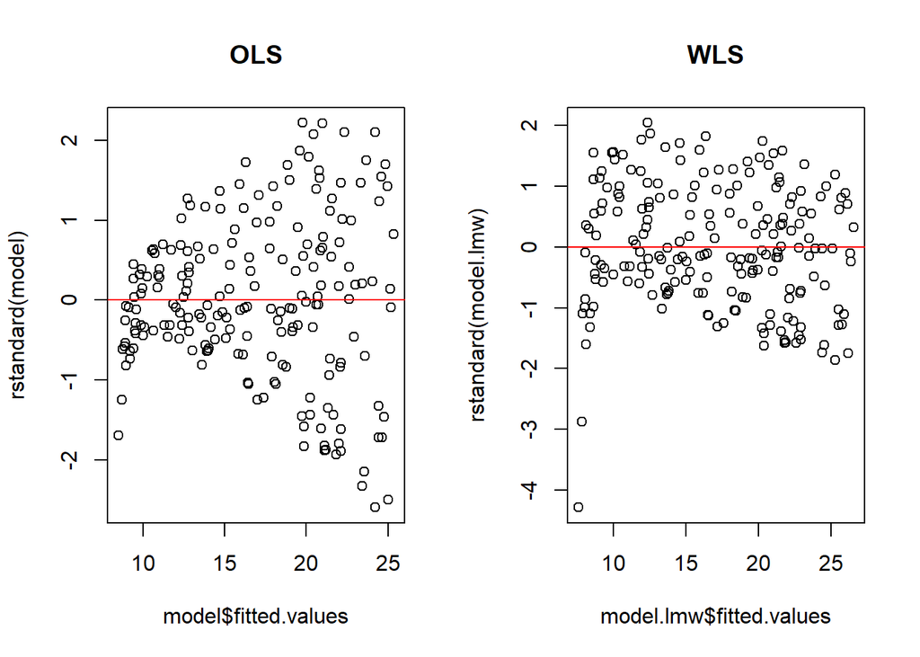

```r
par(mfrow=c(1,2))
plot(y = rstandard(model),
     x = model$fitted.values,
     main="OLS")
abline(h=0, col="red")
plot(y = rstandard(model.lmw),
     x = model.lmw$fitted.values,
     main="WLS")
abline(h=0, col="red")
```

```r
par(mfrow=c(1,1))
```

## Perbandingan Garis Regresi OLS dan WLS

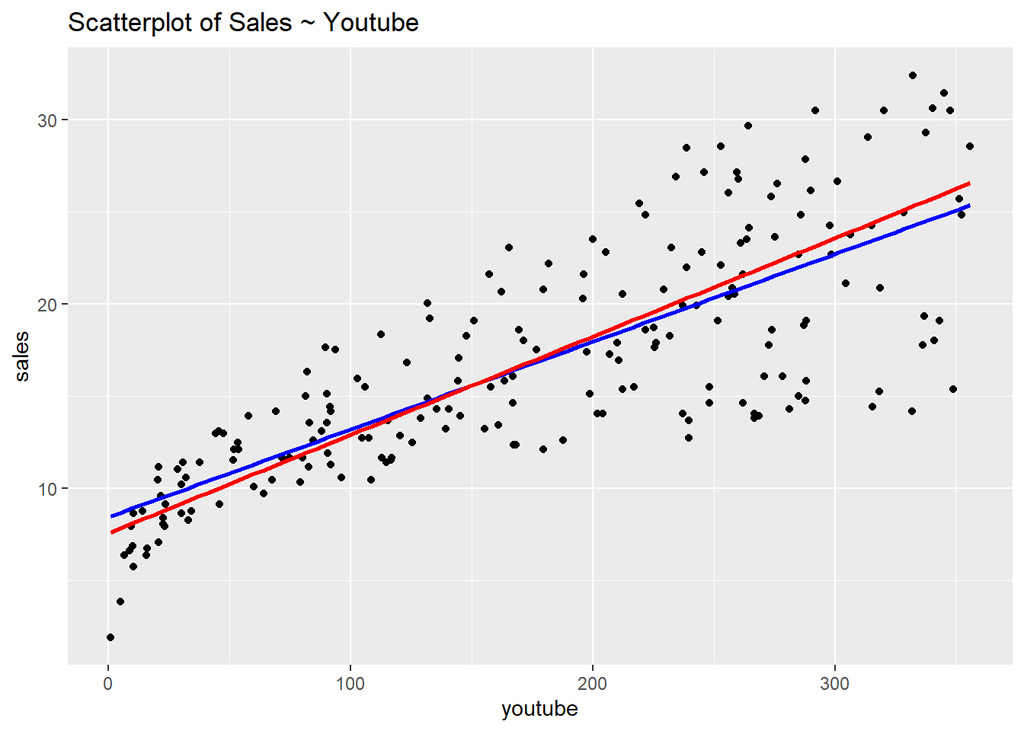

```r
ggplot(data = data, aes(youtube, sales)) +
  geom_point() +
  geom_smooth(method = lm, se = FALSE,
              color = "blue",
              size = 0.9) +
  geom_smooth(method = lm, se = FALSE,
              aes(weight = data.weights),
              color = "red",
              size = 0.9)+
  labs(title = "Scatterplot of Sales ~ Youtube")
```

## Uji Formal

### Nilai harapan sisaan sama dengan nol

```r
t.test(model.lmw$residuals,mu = 0,conf.level = 0.95)
```

```
##
##  One Sample t-test
##
## data:  model.lmw$residuals
## t = -0.53604, df = 199, p-value = 0.5925
## alternative hypothesis: true mean is not equal to 0
## 95 percent confidence interval:
##  -0.6998671  0.4007003
## sample estimates:
##  mean of x
## -0.1495834
```

Nilai p pada uji t sama dengan 0.5925 yang lebih besar dari alpha 5%, sehingga dinyatakan asumsi nilai harapan sisaan sama dengan nol terpenuhi

### Ragam Sisaan Homogen

```r
bptest(model.lmw)
```

```
##
##  studentized Breusch-Pagan test
##
## data:  model.lmw
## BP = 4.9733, df = 1, p-value = 0.02574
```

Nilai p pada uji breusch pagan sama dengan 0.02574 yang masih kurang dari alpha 5%, sehingga dinyatakan asumsi ragam sisaan homogen tidak terpenuhi. Walau demikian nilai ini sudah jauh lebih baik dari sebelumnya

### Normalitas Sisaan

```r
ks.test(model.lmw$residuals, "pnorm", mean = mean(model.lmw$residuals),
        sd = sd(model.lmw$residuals))
```

```
##
##  Asymptotic one-sample Kolmogorov-Smirnov test
##
## data:  model.lmw$residuals
## D = 0.07885, p-value = 0.1662
## alternative hypothesis: two-sided
```